# Initial Results and Code for CIND820 PT2

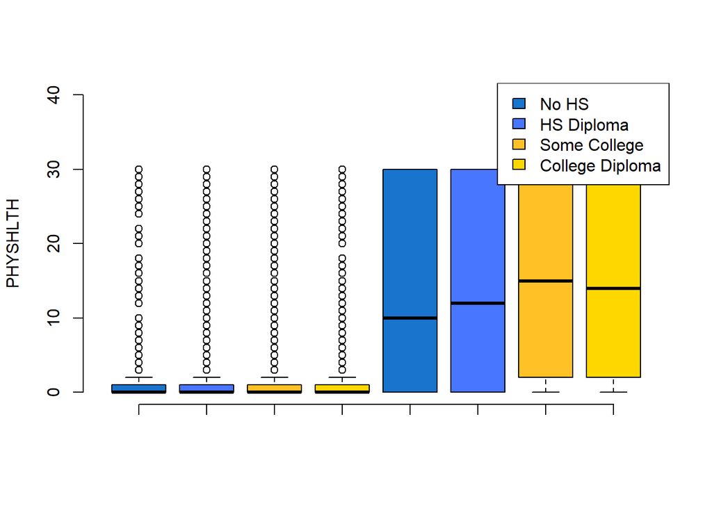

```r
boxplot(PHYSHLTH ~ X_EDUCAG * X_RFHLTH, data, frame=FALSE,
        col = c("dodgerblue3", "royalblue1", "goldenrod1", "gold"),
        xlab="",
        names=c("", "", "", "", "", "", "",""),
        ylim=c(0,40)
        )
legend("topright", legend=c("No HS", "HS Diploma", "Some College", "College Diploma"), fill=c("dodgerblue3", "royalblue1", "goldenrod1", "gold"))
```

The number of days in poor physical health is significantly different across education and self-reported health (p < 0.01). Depending on the education level, respondents with poor self-reported health vary in the number of days spent in poor health.

```r
#PHYSHLTH, DECIDE, X_RFHLTH.
scheirerRayHare(PHYSHLTH ~ as.factor(X_RFHLTH) + as.factor(DECIDE),
                data = data) #no interaction
```

```
##
## DV:  PHYSHLTH
## Observations:  178132
## D:  0.7539758
## MS total:  2644265630
```

```
##                     Df     Sum Sq     H p.value
## X_RFHLTH             1 6.9904e+13 35062  0.0000
## DECIDE               1 4.3038e+12  2159  0.0000
## X_RFHLTH:DECIDE      1 1.6769e+08     0  0.7718
## Residuals       178128 2.6647e+14
```

QLACTLM2 V. OTHER VARIABLES.

```r
theme_set(theme_pubr())
#QLACTM2, X_MICHD, X_RFHLTH.
mantelhaen.test(x=data$QLACTLM2,
                y=data$X_MICHD,
                z=data$X_RFHLTH,
                exact=FALSE)
```

```
##
##  Mantel-Haenszel chi-squared test with continuity correction
##
## data:  data$QLACTLM2 and data$X_MICHD and data$X_RFHLTH
## Mantel-Haenszel X-squared = 1183.8, df = 1, p-value < 2.2e-16
## alternative hypothesis: true common odds ratio is not equal to 1
## 95 percent confidence interval:
##  NA NA
## sample estimates:
## common odds ratio
##          1.652911
```

```r
counts <- aggregate(data$QLACTLM2, by=list(data$X_RFHLTH, data$X_MICHD, data$QLACTLM2), FUN=length)
names(counts) <- c("HLTH", "HRTDIS", "ACTLIM", "FREQ")
counts$HLTH <- ifelse(counts$HLTH==1, "Good", "Poor")
counts$HRTDIS <- ifelse(counts$HRTDIS==1, "HD", "No HD")
counts$ACTLIM <- ifelse(counts$ACTLIM==1, "Activity Limitations", "No Limitations")
counts
```

```
##   HLTH HRTDIS               ACTLIM  FREQ
## 1 Good     HD Activity Limitations  4776
## 2 Poor     HD Activity Limitations  8565
## 3 Good  No HD Activity Limitations 26175
## 4 Poor  No HD Activity Limitations 17016
## 5 Good     HD       No Limitations 10073
## 6 Poor     HD       No Limitations  3621
## 7 Good  No HD       No Limitations 99535
## 8 Poor  No HD       No Limitations 10583
```

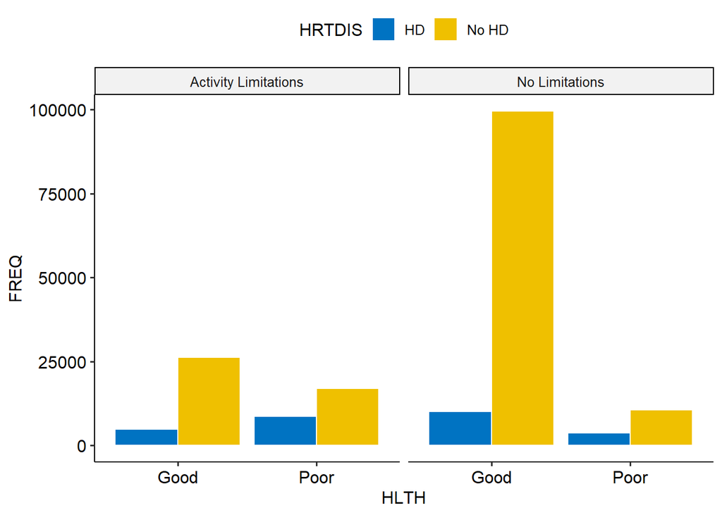

```r
ggplot(counts, aes(x=HLTH, y=FREQ))+geom_bar(aes(fill=HRTDIS),
                                             stat="identity",
                                             color="white",
                                             position=position_dodge(0.9)) + facet_wrap(~ACTLIM)+fill_palette("jco")
```

The counts of respondents with activity limitations is significantly different across heart disease status and self-reported health (p < 0.01).For example, respondents with activity limitations and poor self-reported health have higher proportions of heart disease.

```r
#QLACTLM2, MENTHLTH, X_RFHLTH
scheirerRayHare(MENTHLTH ~ as.factor(X_RFHLTH) + as.factor(QLACTLM2),
                data = data) #interaction
```

```
##
## DV:  MENTHLTH
## Observations:  179519
## D:  0.5434272
## MS total:  2685604240
```

```
##                       Df     Sum Sq      H p.value
## X_RFHLTH               1 6.6523e+12 4558.2       0
## QLACTLM2               1 6.0607e+12 4152.8       0
## X_RFHLTH:QLACTLM2      1 3.8806e+11  265.9       0
## Residuals         179515 2.4119e+14
```

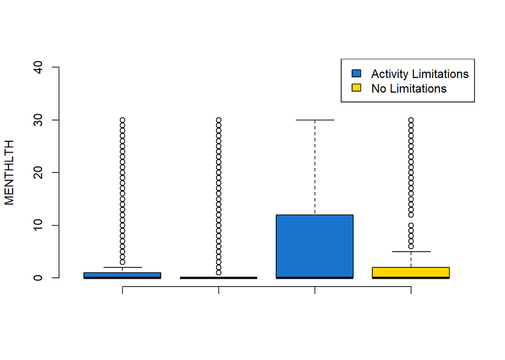

```r
boxplot(MENTHLTH ~ QLACTLM2 * X_RFHLTH, data, frame=FALSE,
        col = c("dodgerblue3", "gold"),
        xlab="",
        names=c("", "", "", ""),
        ylim=c(0,40)
        )
legend("topright", legend=c("Activity Limitations", "No Limitations"), fill=c("dodgerblue3", "gold"))
```

The number of days with poor mental health is significantly different across activity limitations and self-reported health (p < 0.01).For example, respondents with activity limitations and poor self-reported health spend more days with poor mental health compared to other groups.

```r
#QLACTLM2, CHCCOPD1, X_RFHLTH.
mantelhaen.test(x=data$QLACTLM2,
                y=data$CHCCOPD1,
                z=data$X_RFHLTH,
                exact=FALSE)
```

```
##
##  Mantel-Haenszel chi-squared test with continuity correction
##
## data:  data$QLACTLM2 and data$CHCCOPD1 and data$X_RFHLTH
## Mantel-Haenszel X-squared = 2910.1, df = 1, p-value < 2.2e-16
## alternative hypothesis: true common odds ratio is not equal to 1
## 95 percent confidence interval:
##  NA NA
## sample estimates:
## common odds ratio
##          2.387953
```

```r
counts <- aggregate(data$QLACTLM2, by=list(data$X_RFHLTH, data$CHCCOPD1, data$QLACTLM2), FUN=length)
names(counts) <- c("HLTH", "LUNGDIS", "ACTLIM", "FREQ")
counts$HLTH <- ifelse(counts$HLTH==1, "Good", "Poor")
counts$LUNGDIS <- ifelse(counts$LUNGDIS==1, "LD", "No LD")
counts$ACTLIM <- ifelse(counts$ACTLIM==1, "Activity Limitations", "No Limitations")
counts
```

```
##   HLTH LUNGDIS               ACTLIM   FREQ
## 1 Good      LD Activity Limitations   4098
## 2 Poor      LD Activity Limitations   8267
## 3 Good   No LD Activity Limitations  27059
## 4 Poor   No LD Activity Limitations  17559
## 5 Good      LD       No Limitations   6058
## 6 Poor      LD       No Limitations   2554
## 7 Good   No LD       No Limitations 103907
## 8 Poor   No LD       No Limitations  11771
```

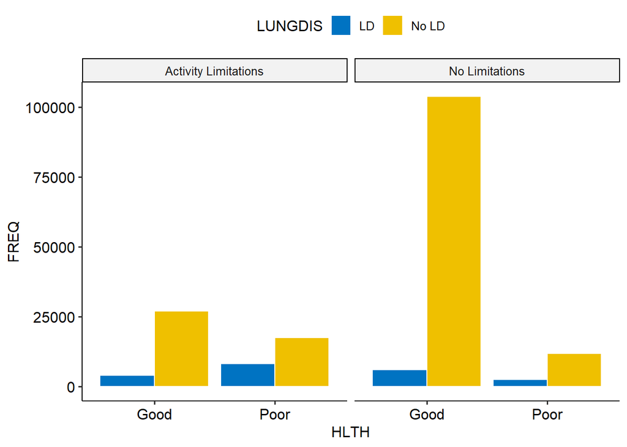

```r
ggplot(counts, aes(x=HLTH, y=FREQ))+geom_bar(aes(fill=LUNGDIS),
                                             stat="identity",
                                             color="white",
                                             position=position_dodge(0.9)) + facet_wrap(~ACTLIM)+fill_palette("jco")
```

The counts of respondents with activity limitations is significantly different across lung disease status and self-reported health (p < 0.01).For example, respondents with activity limitations and poor self-reported health have higher proportions of lung disease.

```r
#QLACTLM2, USEEQUIP, X_RFHLTH.
mantelhaen.test(x=data$QLACTLM2,
                y=data$USEEQUIP,
                z=data$X_RFHLTH,
                exact=FALSE)
```

```
##
##  Mantel-Haenszel chi-squared test with continuity correction
##
## data:  data$QLACTLM2 and data$USEEQUIP and data$X_RFHLTH
## Mantel-Haenszel X-squared = 19787, df = 1, p-value < 2.2e-16
## alternative hypothesis: true common odds ratio is not equal to 1
## 95 percent confidence interval:
##  NA NA
## sample estimates:
## common odds ratio
##          6.723436
```

```r
counts <- aggregate(data$QLACTLM2, by=list(data$X_RFHLTH, data$USEEQUIP, data$QLACTLM2), FUN=length)
names(counts) <- c("HLTH", "USEEQUIP", "ACTLIM", "FREQ")
counts$HLTH <- ifelse(counts$HLTH==1, "Good", "Poor")
counts$USEEQUIP <- ifelse(counts$USEEQUIP==1, "Uses Equip", "No Equip")
counts$ACTLIM <- ifelse(counts$ACTLIM==1, "Activity Limitations", "No Limitations")
counts
```

```
##   HLTH   USEEQUIP               ACTLIM   FREQ
## 1 Good Uses Equip Activity Limitations   9598
## 2 Poor Uses Equip Activity Limitations  14269
## 3 Good   No Equip Activity Limitations  21687
## 4 Poor   No Equip Activity Limitations  11806
## 5 Good Uses Equip       No Limitations   5462
## 6 Poor Uses Equip       No Limitations   2835
## 7 Good   No Equip       No Limitations 104791
## 8 Poor   No Equip       No Limitations  11574
```

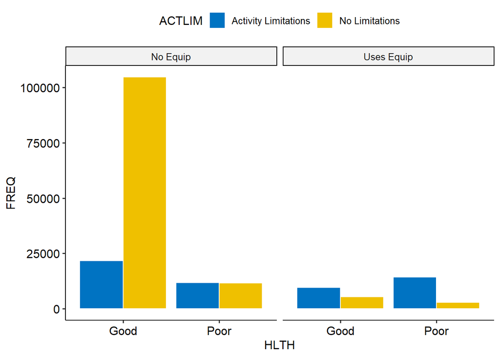

```r
ggplot(counts, aes(x=HLTH, y=FREQ))+geom_bar(aes(fill=ACTLIM),
                                             stat="identity",
                                             color="white",
                                             position=position_dodge(0.9)) + facet_wrap(~USEEQUIP)+fill_palette("jco")
```

The counts of respondents with activity limitations is significantly different across special equipment requirements and self-reported health (p < 0.01).For example, respondents with activity limitations and poor self-reported health have higher proportions of special equipment requirements.

```r
#QLACTLM2, DIABETE3, X_RFHLTH.
mantelhaen.test(x=data$QLACTLM2,
                y=data$DIABETE3,
                z=data$X_RFHLTH,
                exact=FALSE)
```

```
##
##  Mantel-Haenszel chi-squared test with continuity correction
##
## data:  data$QLACTLM2 and data$DIABETE3 and data$X_RFHLTH
## Mantel-Haenszel X-squared = 405.6, df = 1, p-value < 2.2e-16
## alternative hypothesis: true common odds ratio is not equal to 1
## 95 percent confidence interval:
##  NA NA
## sample estimates:
## common odds ratio
##          1.301089
```

```r
counts <- aggregate(data$QLACTLM2, by=list(data$X_RFHLTH, data$DIABETE3, data$QLACTLM2), FUN=length)
names(counts) <- c("HLTH", "DIABETE3", "ACTLIM", "FREQ")
counts$HLTH <- ifelse(counts$HLTH==1, "Good", "Poor")
counts$DIABETE3 <- ifelse(counts$DIABETE3==1, "Diabetes", "No Diabetes")
counts$ACTLIM <- ifelse(counts$ACTLIM==1, "Activity Limitations", "No Limitations")
counts
```

```
##   HLTH    DIABETE3               ACTLIM  FREQ
## 1 Good    Diabetes Activity Limitations  6277
## 2 Poor    Diabetes Activity Limitations  9384
## 3 Good No Diabetes Activity Limitations 25035
## 4 Poor No Diabetes Activity Limitations 16675
## 5 Good    Diabetes       No Limitations 15317
## 6 Poor    Diabetes       No Limitations  5238
## 7 Good No Diabetes       No Limitations 94876
## 8 Poor No Diabetes       No Limitations  9166
```

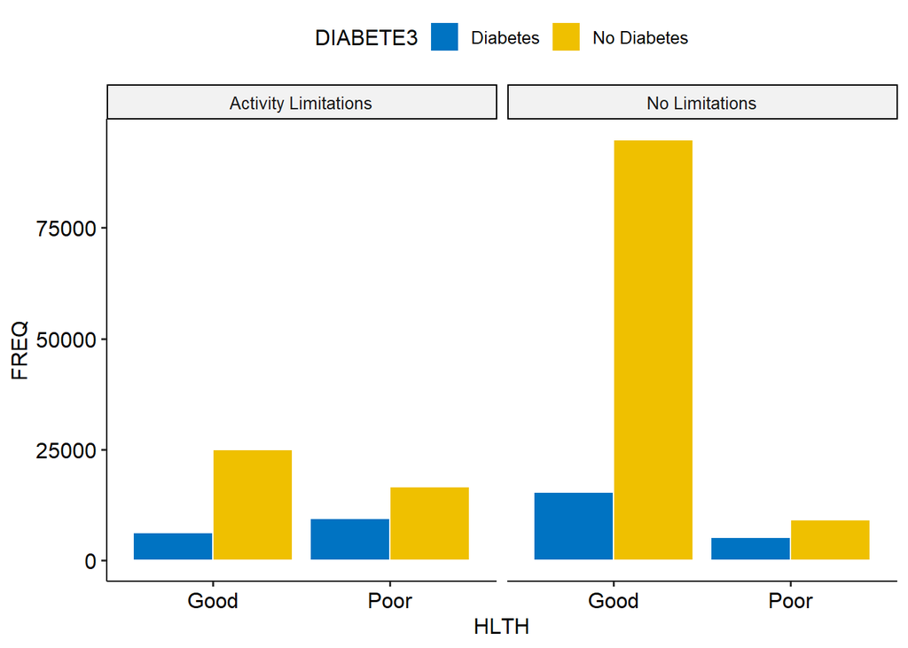

```r
ggplot(counts, aes(x=HLTH, y=FREQ))+geom_bar(aes(fill=DIABETE3),
                                             stat="identity",
                                             color="white",
                                             position=position_dodge(0.9)) + facet_wrap(~ACTLIM)+fill_palette("jco")
```

The counts of respondents with activity limitations is significantly different across diabetes status and self-reported health (p < 0.01).For example, respondents with activity limitations and poor self-reported health have higher proportions of diabetes.

```r
#QLACTLM2, X_EDUCAG, X_RFHLTH.
mantelhaen.test(x=data$QLACTLM2,
                y=data$X_EDUCAG,
                z=data$X_RFHLTH,
                exact=FALSE)
```

```
##
##  Cochran-Mantel-Haenszel test
##
## data:  data$QLACTLM2 and data$X_EDUCAG and data$X_RFHLTH
## Cochran-Mantel-Haenszel M^2 = 600.77, df = 3, p-value < 2.2e-16
```

```r
counts <- aggregate(data$QLACTLM2, by=list(data$X_RFHLTH, data$X_EDUCAG, data$QLACTLM2), FUN=length)
names(counts) <- c("HLTH", "X_EDUCAG", "ACTLIM", "FREQ")
counts$HLTH <- ifelse(counts$HLTH==1, "Good", "Poor")
counts$X_EDUCAG <- ifelse(counts$X_EDUCAG==1, "No HS", ifelse(counts$X_EDUCAG==2, "HS", ifelse(counts$X_EDUCAG==3, "Some CD", "CD")))
counts$ACTLIM <- ifelse(counts$ACTLIM==1, "Activity Limitations", "No Limitations")
counts
```

```
##    HLTH X_EDUCAG               ACTLIM  FREQ
## 1  Good    No HS Activity Limitations  1625
## 2  Poor    No HS Activity Limitations  3750
## 3  Good       HS Activity Limitations  7825
## 4  Poor       HS Activity Limitations  8965
## 5  Good  Some CD Activity Limitations  9189
## 6  Poor  Some CD Activity Limitations  7458
## 7  Good       CD Activity Limitations 12658
## 8  Poor       CD Activity Limitations  5876
## 9  Good    No HS       No Limitations  5745
## 10 Poor    No HS       No Limitations  3257
## 11 Good       HS       No Limitations 30547
## 12 Poor       HS       No Limitations  5689
## 13 Good  Some CD       No Limitations 29085
## 14 Poor  Some CD       No Limitations  3048
## 15 Good       CD       No Limitations 44740
## 16 Poor       CD       No Limitations  2380
```

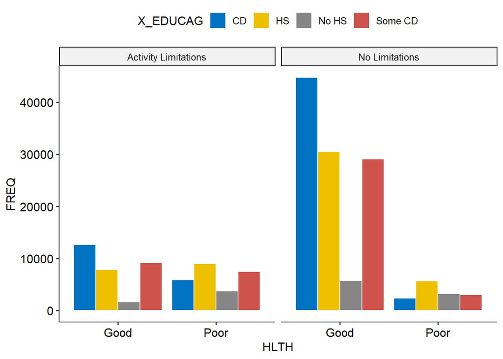

```r
ggplot(counts, aes(x=HLTH, y=FREQ))+geom_bar(aes(fill=X_EDUCAG),
                                             stat="identity",
                                             color="white",
                                             position=position_dodge(0.9)) + facet_wrap(~ACTLIM)+fill_palette("jco")
```

The counts of respondents with activity limitations is significantly different across education and self-reported health (p < 0.01).For example, respondents with activity limitations and poor self-reported health have higher proportions of no high school or high school education level.

```r
#QLACTLM2, DECIDE, X_RFHLTH.
mantelhaen.test(x=data$QLACTLM2,
                y=data$DECIDE,
                z=data$X_RFHLTH,
                exact=FALSE)
```

```
##
##  Mantel-Haenszel chi-squared test with continuity correction
##
## data:  data$QLACTLM2 and data$DECIDE and data$X_RFHLTH
## Mantel-Haenszel X-squared = 4333.8, df = 1, p-value < 2.2e-16
## alternative hypothesis: true common odds ratio is not equal to 1
## 95 percent confidence interval:
##  NA NA
## sample estimates:
## common odds ratio
##          3.324768
```

```r
counts <- aggregate(data$QLACTLM2, by=list(data$X_RFHLTH, data$DECIDE, data$QLACTLM2), FUN=length)
names(counts) <- c("HLTH", "COGDEF", "ACTLIM", "FREQ")
counts$HLTH <- ifelse(counts$HLTH==1, "Good", "Poor")
counts$COGDEF <- ifelse(counts$COGDEF==1, "Deficits", "No Deficits")
counts$ACTLIM <- ifelse(counts$ACTLIM==1, "Activity Limitations", "No Limitations")
counts
```

```
##   HLTH      COGDEF               ACTLIM   FREQ
## 1 Good    Deficits Activity Limitations   3550
## 2 Poor    Deficits Activity Limitations   7132
## 3 Good No Deficits Activity Limitations  27589
## 4 Poor No Deficits Activity Limitations  18732
## 5 Good    Deficits       No Limitations   3429
## 6 Poor    Deficits       No Limitations   1736
## 7 Good No Deficits       No Limitations 106597
## 8 Poor No Deficits       No Limitations  12608
```

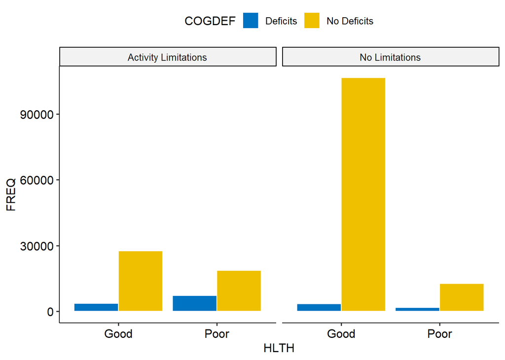

```r
ggplot(counts, aes(x=HLTH, y=FREQ))+geom_bar(aes(fill=COGDEF),
                                             stat="identity",
                                             color="white",
                                             position=position_dodge(0.9)) + facet_wrap(~ACTLIM)+fill_palette("jco")
```

The counts of respondents with activity limitations is significantly different across cognitive deficits and self-reported health (p < 0.01).For example, respondents with activity limitations and poor self-reported health have higher proportions of cognitive deficits.

HEART DISEASE V. OTHER TOP TEN VARIABLES.

```r
#X_MICHD, MENTHLTH, X_RFHLTH
scheirerRayHare(MENTHLTH ~ as.factor(X_RFHLTH) + as.factor(X_MICHD),
                data = data) #no interaction
```

```
##
## DV:  MENTHLTH
## Observations:  178680
## D:  0.5428211
## MS total:  2660560090
```

```
##                      Df     Sum Sq      H  p.value
## X_RFHLTH              1 1.3083e+13 9059.0 0.000000
## X_MICHD               1 1.2378e+10    8.6 0.003416
## X_RFHLTH:X_MICHD      1 6.5562e+09    4.5 0.033119
## Residuals        178676 2.4400e+14
```

```r
#X_MICHD, CHCCOPD1, X_RFHLTH.
mantelhaen.test(x=data$X_MICHD,
                y=data$CHCCOPD1,
                z=data$X_RFHLTH,
                exact=FALSE)
```

```
##
##  Mantel-Haenszel chi-squared test with continuity correction
##
## data:  data$X_MICHD and data$CHCCOPD1 and data$X_RFHLTH
## Mantel-Haenszel X-squared = 1694.8, df = 1, p-value < 2.2e-16
## alternative hypothesis: true common odds ratio is not equal to 1
## 95 percent confidence interval:
##  NA NA
## sample estimates:
## common odds ratio
##          2.044253
```

```r
counts <- aggregate(data$X_MICHD, by=list(data$X_RFHLTH, data$CHCCOPD1, data$X_MICHD), FUN=length)
names(counts) <- c("HLTH", "LUNGDIS", "X_MICHD", "FREQ")
counts$HLTH <- ifelse(counts$HLTH==1, "Good", "Poor")
counts$LUNGDIS <- ifelse(counts$LUNGDIS==1, "LD", "No LD")
counts$X_MICHD <- ifelse(counts$X_MICHD==1, "HD", "No HD")
counts
```

```
##   HLTH LUNGDIS X_MICHD   FREQ
## 1 Good      LD      HD   2140
## 2 Poor      LD      HD   4244
## 3 Good   No LD      HD  12689
## 4 Poor   No LD      HD   7860
## 5 Good      LD   No HD   7946
## 6 Poor      LD   No HD   6404
## 7 Good   No LD   No HD 118020
## 8 Poor   No LD   No HD  21162
```

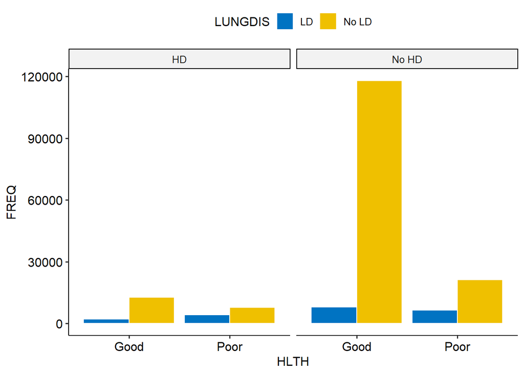

```r
ggplot(counts, aes(x=HLTH, y=FREQ))+geom_bar(aes(fill=LUNGDIS),
                                             stat="identity",
                                             color="white",
                                             position=position_dodge(0.9)) + facet_wrap(~X_MICHD)+fill_palette("jco") #TK change colour
```

The counts of respondents with heart disease is significantly different across lung disease status and self-reported health (p < 0.01).For example, respondents with heart disease and poor self-reported health have higher proportions of lung disease.

```r
#X_MICHD, USEEQUIP, X_RFHLTH.
mantelhaen.test(x=data$X_MICHD,
                y=data$USEEQUIP,
                z=data$X_RFHLTH,
                exact=FALSE)
```

```
##
##  Mantel-Haenszel chi-squared test with continuity correction
##
## data:  data$X_MICHD and data$USEEQUIP and data$X_RFHLTH
## Mantel-Haenszel X-squared = 1138.4, df = 1, p-value < 2.2e-16
## alternative hypothesis: true common odds ratio is not equal to 1
## 95 percent confidence interval:
##  NA NA
## sample estimates:
## common odds ratio
##          1.706969
```

```r
counts <- aggregate(data$X_MICHD, by=list(data$X_RFHLTH, data$USEEQUIP, data$X_MICHD), FUN=length)
names(counts) <- c("HLTH", "USEEQUIP", "X_MICHD", "FREQ")
counts$HLTH <- ifelse(counts$HLTH==1, "Good", "Poor")
counts$USEEQUIP <- ifelse(counts$USEEQUIP==1, "Uses Equip", "No Equip")
counts$X_MICHD <- ifelse(counts$X_MICHD==1, "HD", "No HD")
counts
```

```
##   HLTH   USEEQUIP X_MICHD   FREQ
## 1 Good Uses Equip      HD   2690
## 2 Poor Uses Equip      HD   5985
## 3 Good   No Equip      HD  12232
## 4 Poor   No Equip      HD   6257
## 5 Good Uses Equip   No HD  12241
## 6 Poor Uses Equip   No HD  10833
## 7 Good   No Equip   No HD 114025
## 8 Poor   No Equip   No HD  16912
```

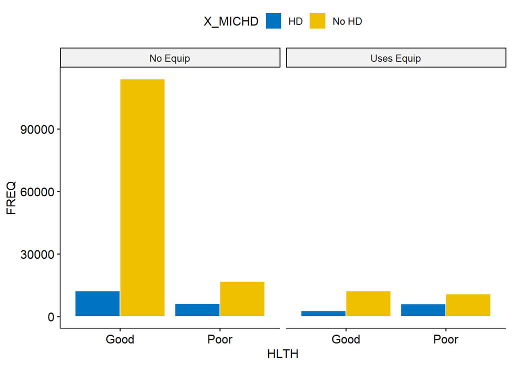

```r
ggplot(counts, aes(x=HLTH, y=FREQ))+geom_bar(aes(fill=X_MICHD),
                                             stat="identity",
                                             color="white",
                                             position=position_dodge(0.9)) + facet_wrap(~USEEQUIP)+fill_palette("jco")
```

The counts of respondents with heart disease is significantly different across special equipment requirements and self-reported health (p < 0.01).For example, respondents with heart disease and poor self-reported health have higher proportions of special equipment requirements.

```r
#X_MICHD, DIABETE3, X_RFHLTH.
mantelhaen.test(x=data$X_MICHD,
                y=data$DIABETE3,
                z=data$X_RFHLTH,
                exact=FALSE)
```

```
##
##  Mantel-Haenszel chi-squared test with continuity correction
##
## data:  data$X_MICHD and data$DIABETE3 and data$X_RFHLTH
## Mantel-Haenszel X-squared = 1539, df = 1, p-value < 2.2e-16
## alternative hypothesis: true common odds ratio is not equal to 1
## 95 percent confidence interval:
##  NA NA
## sample estimates:
## common odds ratio
##          1.794338
```

```r
counts <- aggregate(data$X_MICHD, by=list(data$X_RFHLTH, data$DIABETE3, data$X_MICHD), FUN=length)
names(counts) <- c("HLTH", "DIABETE3", "X_MICHD", "FREQ")
counts$HLTH <- ifelse(counts$HLTH==1, "Good", "Poor")
counts$DIABETE3 <- ifelse(counts$DIABETE3==1, "Yes", "No")
counts$X_MICHD <- ifelse(counts$X_MICHD==1, "HD", "No HD")
counts
```

```
##   HLTH DIABETE3 X_MICHD   FREQ
## 1 Good      Yes      HD   3833
## 2 Poor      Yes      HD   5238
## 3 Good       No      HD  11085
## 4 Poor       No      HD   7001
## 5 Good      Yes   No HD  17676
## 6 Poor      Yes   No HD   9188
## 7 Good       No   No HD 108569
## 8 Poor       No   No HD  18545
```

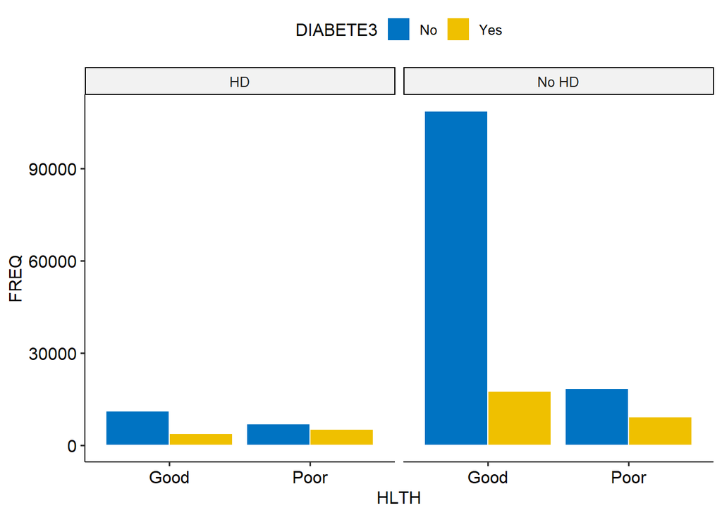

```r
ggplot(counts, aes(x=HLTH, y=FREQ))+geom_bar(aes(fill=DIABETE3),
                                             stat="identity",
                                             color="white",
                                             position=position_dodge(0.9)) + facet_wrap(~X_MICHD)+fill_palette("jco") #TK change colour
```

The counts of respondents with heart disease is significantly different across diabetes status and self-reported health (p < 0.01).For example, respondents with heart disease and poor self-reported health have higher proportions of diabetes.

```r
#X_MICHD, X_EDUCAG, X_RFHLTH.
mantelhaen.test(x=data$X_MICHD,
                y=data$X_EDUCAG,
                z=data$X_RFHLTH,
                exact=FALSE)
```

```
##
##  Cochran-Mantel-Haenszel test
##
## data:  data$X_MICHD and data$X_EDUCAG and data$X_RFHLTH
## Cochran-Mantel-Haenszel M^2 = 175.21, df = 3, p-value < 2.2e-16
```

```r
counts <- aggregate(data$X_MICHD, by=list(data$X_RFHLTH, data$X_EDUCAG, data$X_MICHD), FUN=length)
names(counts) <- c("HLTH", "X_EDUCAG", "X_MICHD", "FREQ")
counts$HLTH <- ifelse(counts$HLTH==1, "Good", "Poor")
counts$X_EDUCAG <- ifelse(counts$X_EDUCAG==1, "No HS", ifelse(counts$X_EDUCAG==2, "HS", ifelse(counts$X_EDUCAG==3, "Some CD", "CD")))
counts$X_MICHD <- ifelse(counts$X_MICHD==1, "HD", "No HD")
counts
```

```
##    HLTH X_EDUCAG X_MICHD  FREQ
## 1  Good    No HS      HD  1101
## 2  Poor    No HS      HD  2079
## 3  Good       HS      HD  4405
## 4  Poor       HS      HD  4374
## 5  Good  Some CD      HD  4122
## 6  Poor  Some CD      HD  3317
## 7  Good       CD      HD  5287
## 8  Poor       CD      HD  2451
## 9  Good    No HS   No HD  6214
## 10 Poor    No HS   No HD  4811
## 11 Good       HS   No HD 33783
## 12 Poor       HS   No HD 10070
## 13 Good  Some CD   No HD 34078
## 14 Poor  Some CD   No HD  7058
## 15 Good       CD   No HD 52080
## 16 Poor       CD   No HD  5768
```

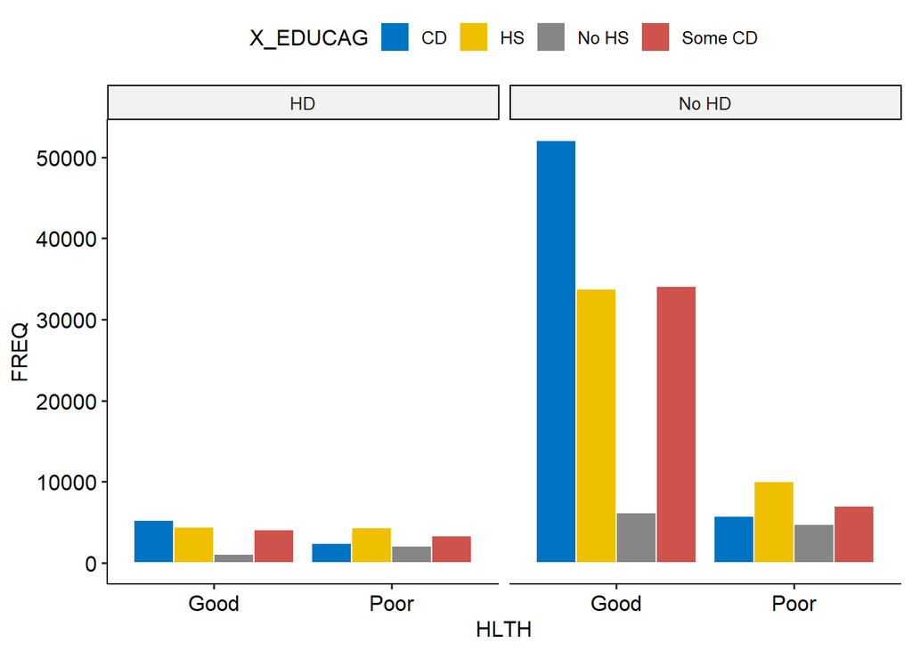

```r
ggplot(counts, aes(x=HLTH, y=FREQ))+geom_bar(aes(fill=X_EDUCAG),
                                             stat="identity",
                                             color="white",
                                             position=position_dodge(0.9)) + facet_wrap(~X_MICHD)+fill_palette("jco") #TK change colour
```

The counts of respondents with heart disease is significantly different across education and self-reported health (p < 0.01).For example, respondents with heart disease and poor self-reported health have lower proportions of college degrees.

```r
#X_MICHD, DECIDE, X_RFHLTH.
mantelhaen.test(x=data$X_MICHD,
                y=data$DECIDE,
                z=data$X_RFHLTH,
                exact=FALSE)
```

```
##
##  Mantel-Haenszel chi-squared test with continuity correction
##
## data:  data$X_MICHD and data$DECIDE and data$X_RFHLTH
## Mantel-Haenszel X-squared = 273.44, df = 1, p-value < 2.2e-16
## alternative hypothesis: true common odds ratio is not equal to 1
## 95 percent confidence interval:
##  NA NA
## sample estimates:
## common odds ratio
##          1.396865
```

```r
counts <- aggregate(data$X_MICHD, by=list(data$X_RFHLTH, data$DECIDE, data$X_MICHD), FUN=length)
names(counts) <- c("HLTH", "COGDEF", "X_MICHD", "FREQ")
counts$HLTH <- ifelse(counts$HLTH==1, "Good", "Poor")
counts$COGDEF <- ifelse(counts$COGDEF==1, "Deficits", "No Deficits")
counts$X_MICHD <- ifelse(counts$X_MICHD==1, "HD", "No HD")
counts
```

```
##   HLTH      COGDEF X_MICHD   FREQ
## 1 Good    Deficits      HD   1213
## 2 Poor    Deficits      HD   2942
## 3 Good No Deficits      HD  13661
## 4 Poor No Deficits      HD   9206
## 5 Good    Deficits   No HD   5721
## 6 Poor    Deficits   No HD   5787
## 7 Good No Deficits   No HD 120208
## 8 Poor No Deficits   No HD  21782
```

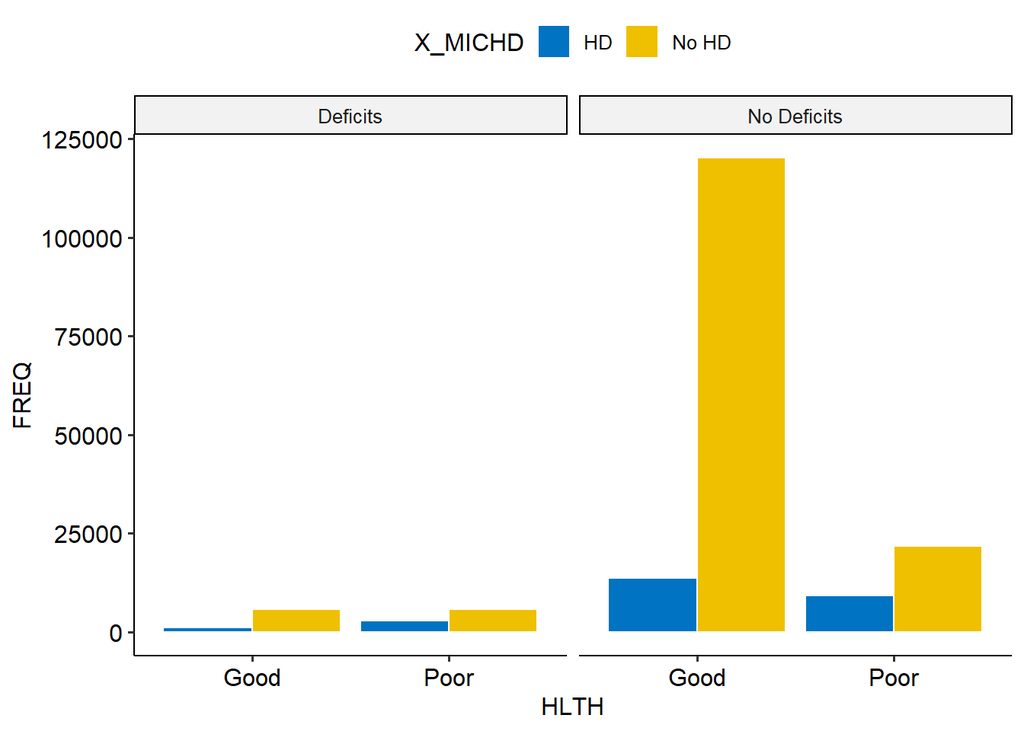

```r
ggplot(counts, aes(x=HLTH, y=FREQ))+geom_bar(aes(fill=X_MICHD),
                                             stat="identity",
                                             color="white",
                                             position=position_dodge(0.9)) + facet_wrap(~COGDEF)+fill_palette("jco") #TK change colour
```

The counts of respondents with heart disease is significantly different across cognitive deficits and self-reported health (p < 0.01).For example, respondents with heart disease and poor self-reported health have higher proportions of cognitive deficits.

MENTAL HEALTH DAYS V. OTHER VARIABLES.

```r
#MENTHLTH, CHCCOPD1, X_RFHLTH
scheirerRayHare(MENTHLTH ~ as.factor(X_RFHLTH) + as.factor(CHCCOPD1),
                data = data) #interaction
```

```
##
## DV:  MENTHLTH
## Observations:  179593
## D:  0.5427641
## MS total:  2687818770
```

```
##                       Df     Sum Sq      H   p.value
## X_RFHLTH               1 1.1270e+13 7725.0 0.0000000
## CHCCOPD1               1 1.2372e+12  848.1 0.0000000
## X_RFHLTH:CHCCOPD1      1 9.9485e+09    6.8 0.0090172
## Residuals         179589 2.4656e+14
```

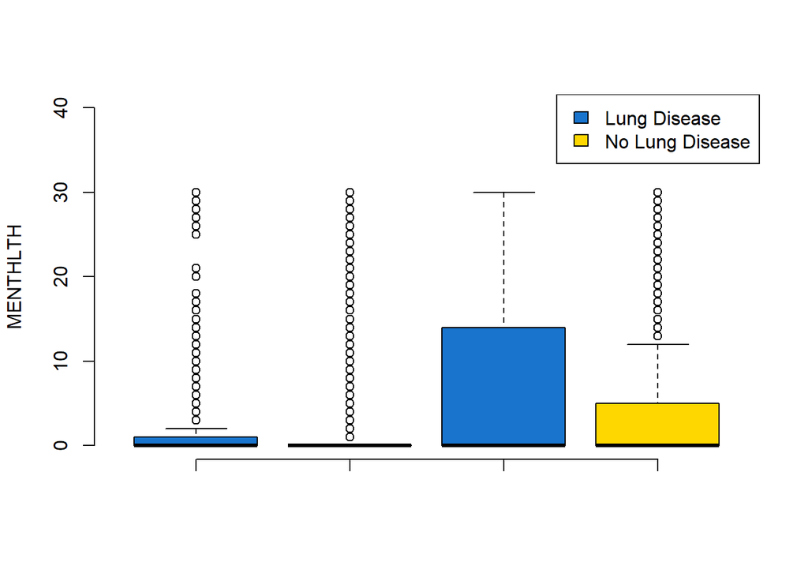

```r
boxplot(MENTHLTH ~ CHCCOPD1 * X_RFHLTH, data, frame=FALSE,
        col = c("dodgerblue3", "gold"),
        xlab="",
        names=c("", "", "", ""),
        ylim=c(0,40)
        )
legend("topright", legend=c("Lung Disease", "No Lung Disease"), fill=c("dodgerblue3", "gold"))
```

The number of days with poor mental health is significantly different across lung disease status and self-reported health (p < 0.01).For example, respondents with lung disease and poor self-reported health spend more days with poor mental health compared to other groups.

```r
#MENTHLTH, USEEQUIP, X_RFHLTH
scheirerRayHare(MENTHLTH ~ as.factor(X_RFHLTH) + as.factor(USEEQUIP),
                data = data) #interaction
```

```
##
## DV:  MENTHLTH
## Observations:  180323
## D:  0.5438804
## MS total:  2709713721
```

```
##                       Df     Sum Sq      H    p.value
## X_RFHLTH               1 1.0142e+13 6881.7 0.0000e+00
## USEEQUIP               1 1.3317e+12  903.6 0.0000e+00
## X_RFHLTH:USEEQUIP      1 3.7910e+10   25.7 3.9405e-07
## Residuals         180319 2.4986e+14
```

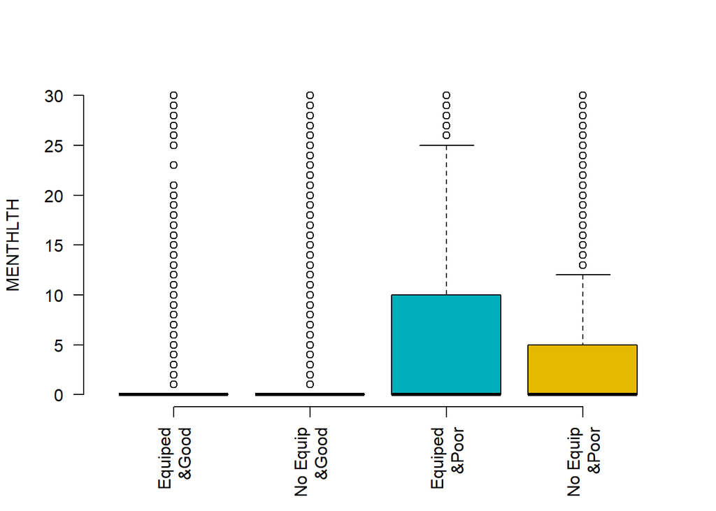

```r
boxplot(MENTHLTH ~ USEEQUIP * X_RFHLTH, data, frame=FALSE,
        col = c("#00AFBB", "#E7B800"),
        names = c("Equiped\n&Good","No Equip\n&Good",
                  "Equiped\n&Poor", "No Equip\n&Poor"),
        xlab="",
        las=2)
```

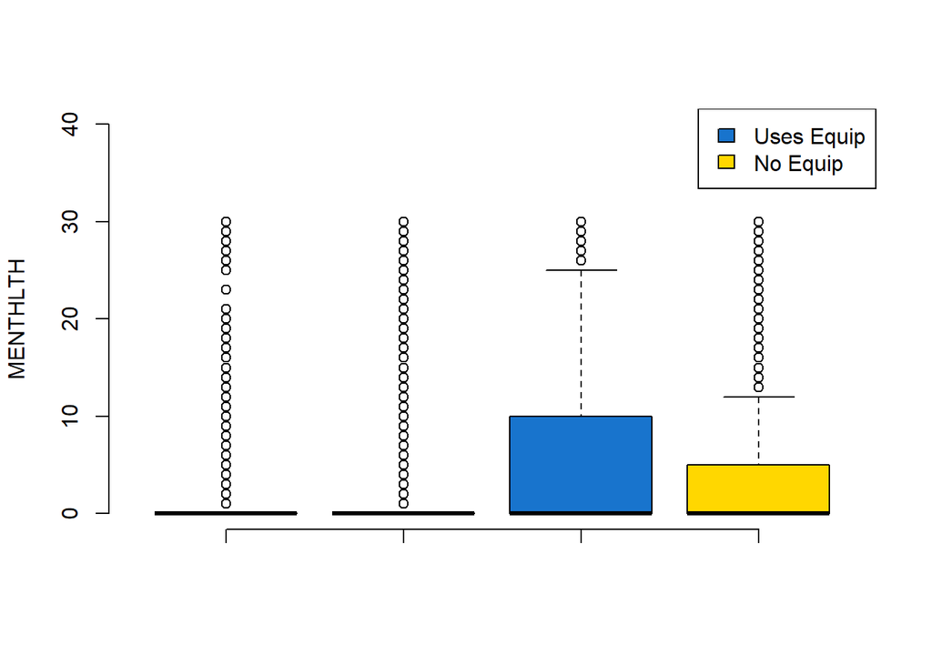

```r
boxplot(MENTHLTH ~ USEEQUIP * X_RFHLTH, data, frame=FALSE,
        col = c("dodgerblue3", "gold"),
        xlab="",
        names=c("", "", "", ""),
        ylim=c(0,40)
        )
legend("topright", legend=c("Uses Equip", "No Equip"), fill=c("dodgerblue3", "gold"))
```

The number of days with poor mental health is significantly different across special equipment requirements and self-reported health (p < 0.01).For example, respondents with special equipment requirements and poor self-reported health spend more days with poor mental health compared to other groups.

```r
#MENTHLTH, DIABETE3, X_RFHLTH
scheirerRayHare(MENTHLTH ~ as.factor(X_RFHLTH) + as.factor(DIABETE3),
                data = data) #no interaction
```

```
##
## DV:  MENTHLTH
## Observations:  180280
## D:  0.5437514
## MS total:  2708421557
```

```
##                       Df     Sum Sq      H p.value
## X_RFHLTH               1 1.3463e+13 9141.6 0.00000
## DIABETE3               1 4.0404e+10   27.4 0.00000
## X_RFHLTH:DIABETE3      1 3.5551e+09    2.4 0.12026
## Residuals         180276 2.5099e+14
```

```r
#MENTHLTH, X_EDUCAG, X_RFHLTH
scheirerRayHare(MENTHLTH ~ as.factor(X_RFHLTH) + as.factor(X_EDUCAG),
                data = data) #no interaction
```

```
##
## DV:  MENTHLTH
## Observations:  180149
## D:  0.5440388
## MS total:  2704486863
```

```
##                       Df     Sum Sq      H   p.value
## X_RFHLTH               1 1.3528e+13 9194.4 0.0000000
## X_EDUCAG               3 1.3651e+11   92.8 0.0000000
## X_RFHLTH:X_EDUCAG      3 2.1775e+10   14.8 0.0019963
## Residuals         180141 2.5040e+14
```

```r
#MENTHLTH, DECIDE, X_RFHLTH
scheirerRayHare(MENTHLTH ~ as.factor(X_RFHLTH) + as.factor(DECIDE),
                data = data) #interaction
```

```
##
## DV:  MENTHLTH
## Observations:  179690
## D:  0.542306
## MS total:  2690722983
```

```
##                     Df     Sum Sq       H    p.value
## X_RFHLTH             1 7.0931e+12  4861.0 0.0000e+00
## DECIDE               1 1.5671e+13 10739.8 0.0000e+00
## X_RFHLTH:DECIDE      1 8.1095e+10    55.6 8.9928e-14
## Residuals       179686 2.3221e+14
```

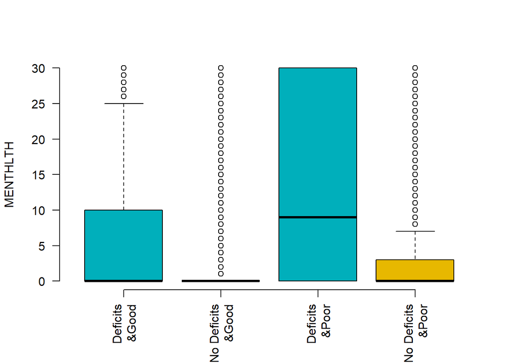

```r
boxplot(MENTHLTH ~ DECIDE * X_RFHLTH, data, frame=FALSE,
        col = c("#00AFBB", "#E7B800"),
        names = c("Deficits\n&Good","No Deficits\n&Good",
                  "Deficits\n&Poor", "No Deficits\n&Poor"),
        xlab="",
        las=2)
```

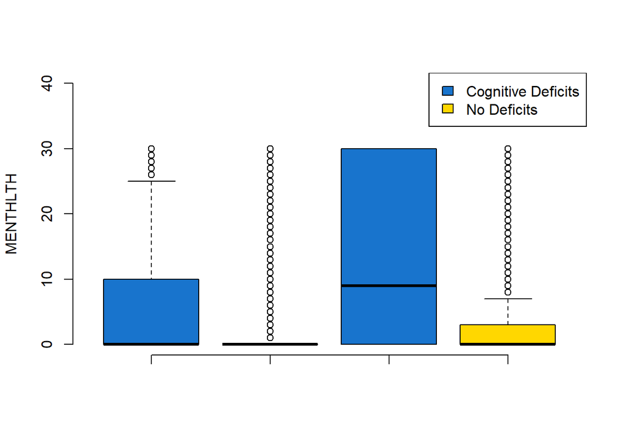

```r
boxplot(MENTHLTH ~ DECIDE * X_RFHLTH, data, frame=FALSE,
        col = c("dodgerblue3", "gold"),
        xlab="",
        names=c("", "", "", ""),
        ylim=c(0,40)
        )
legend("topright", legend=c("Cognitive Deficits", "No Deficits"), fill=c("dodgerblue3", "gold"))
```

The number of days with poor mental health is significantly different across cognitive deficits and self-reported health (p < 0.01).For example, respondents with cognitive deficits and poor self-reported health spend more days with poor mental health compared to other groups.

CHCCOPD1 V. OTHER VARIABLES.

```r
#CHCCOPD1, USEEQUIP, X_RFHLTH.
mantelhaen.test(x=data$CHCCOPD1,
                y=data$USEEQUIP,
                z=data$X_RFHLTH,
                exact=FALSE)
```

```
##
##  Mantel-Haenszel chi-squared test with continuity correction
##
## data:  data$CHCCOPD1 and data$USEEQUIP and data$X_RFHLTH
## Mantel-Haenszel X-squared = 1518.7, df = 1, p-value < 2.2e-16
## alternative hypothesis: true common odds ratio is not equal to 1
## 95 percent confidence interval:
##  NA NA
## sample estimates:
## common odds ratio
##          1.932783
```

```r
counts <- aggregate(data$CHCCOPD1, by=list(data$X_RFHLTH, data$USEEQUIP, data$CHCCOPD1), FUN=length)
names(counts) <- c("HLTH", "USEEQUIP", "CHCCOPD1", "FREQ")
counts$HLTH <- ifelse(counts$HLTH==1, "Good", "Poor")
counts$USEEQUIP <- ifelse(counts$USEEQUIP==1, "Uses Equip", "No Equip")
counts$CHCCOPD1 <- ifelse(counts$CHCCOPD1==1, "LD", "No LD")
counts
```

```
##   HLTH   USEEQUIP CHCCOPD1   FREQ
## 1 Good Uses Equip       LD   2144
## 2 Poor Uses Equip       LD   5593
## 3 Good   No Equip       LD   8064
## 4 Poor   No Equip       LD   5278
## 5 Good Uses Equip    No LD  12920
## 6 Poor Uses Equip    No LD  11394
## 7 Good   No Equip    No LD 118629
## 8 Poor   No Equip    No LD  18086
```

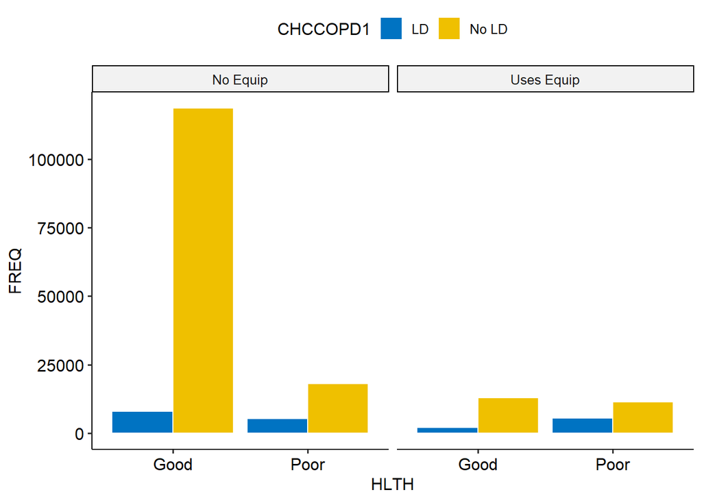

```r
ggplot(counts, aes(x=HLTH, y=FREQ))+geom_bar(aes(fill=CHCCOPD1),
                                             stat="identity",
                                             color="white",
                                             position=position_dodge(0.9)) + facet_wrap(~USEEQUIP)+fill_palette("jco") #TK change colour
```

The counts of respondents with special equipment requirements is significantly different across lung disease and self-reported health (p < 0.01).For example, respondents with lung disease and poor self-reported health have higher proportions of special equipment requirements.

```r
#CHCCOPD1, DIABETE3, X_RFHLTH.
mantelhaen.test(x=data$CHCCOPD1,
                y=data$DIABETE3,
                z=data$X_RFHLTH,
                exact=FALSE)
```

```
##
##  Mantel-Haenszel chi-squared test with continuity correction
##
## data:  data$CHCCOPD1 and data$DIABETE3 and data$X_RFHLTH
## Mantel-Haenszel X-squared = 29.823, df = 1, p-value = 4.733e-08
## alternative hypothesis: true common odds ratio is not equal to 1
## 95 percent confidence interval:
##  NA NA
## sample estimates:
## common odds ratio
##          1.099569
```

```r
counts <- aggregate(data$CHCCOPD1, by=list(data$X_RFHLTH, data$DIABETE3, data$CHCCOPD1), FUN=length)
names(counts) <- c("HLTH", "DIABETE3", "CHCCOPD1", "FREQ")
counts$HLTH <- ifelse(counts$HLTH==1, "Good", "Poor")
counts$DIABETE3 <- ifelse(counts$DIABETE3==1, "Yes", "No")
counts$CHCCOPD1 <- ifelse(counts$CHCCOPD1==1, "LD", "No LD")
counts
```

```
##   HLTH DIABETE3 CHCCOPD1   FREQ
## 1 Good      Yes       LD   2033
## 2 Poor      Yes       LD   3746
## 3 Good       No       LD   8178
## 4 Poor       No       LD   7110
## 5 Good      Yes    No LD  19579
## 6 Poor      Yes    No LD  10817
## 7 Good       No    No LD 111945
## 8 Poor       No    No LD  18661
```

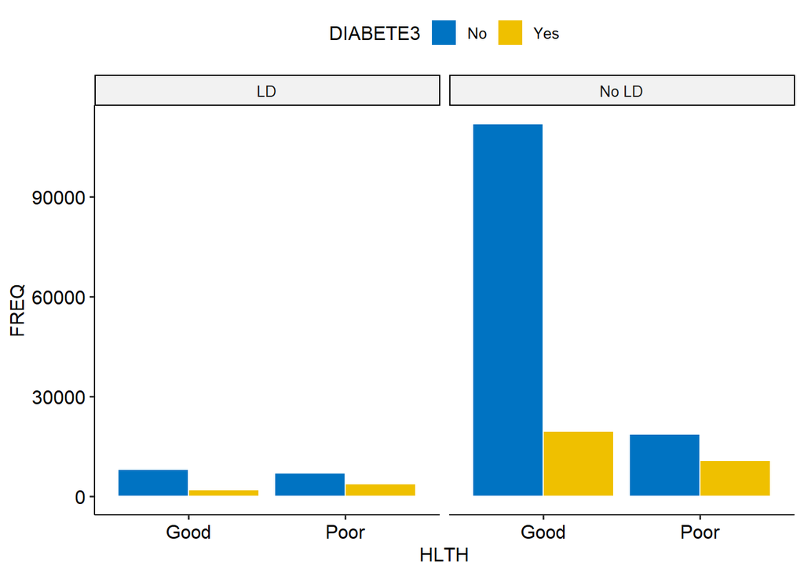

```r
ggplot(counts, aes(x=HLTH, y=FREQ))+geom_bar(aes(fill=DIABETE3),
                                             stat="identity",
                                             color="white",
                                             position=position_dodge(0.9)) + facet_wrap(~CHCCOPD1)+fill_palette("jco") #TK change colour
```

```r
#CHCCOPD1, X_EDUCAG, X_RFHLTH.
mantelhaen.test(x=data$CHCCOPD1,
                y=data$X_EDUCAG,
                z=data$X_RFHLTH,
                exact=FALSE)
```

```
##
##  Cochran-Mantel-Haenszel test
##
## data:  data$CHCCOPD1 and data$X_EDUCAG and data$X_RFHLTH
## Cochran-Mantel-Haenszel M^2 = 1044.9, df = 3, p-value < 2.2e-16
```

```r
counts <- aggregate(data$CHCCOPD1, by=list(data$X_RFHLTH, data$X_EDUCAG, data$CHCCOPD1), FUN=length)
names(counts) <- c("HLTH", "X_EDUCAG", "CHCCOPD1", "FREQ")
counts$HLTH <- ifelse(counts$HLTH==1, "Good", "Poor")
counts$X_EDUCAG <- ifelse(counts$X_EDUCAG==1, "No HS", ifelse(counts$X_EDUCAG==2, "HS", ifelse(counts$X_EDUCAG==3, "Some CD", "CD")))
counts$CHCCOPD1 <- ifelse(counts$CHCCOPD1==1, "LD", "No LD")
counts
```

```
##    HLTH X_EDUCAG CHCCOPD1  FREQ
## 1  Good    No HS       LD   834
## 2  Poor    No HS       LD  2016
## 3  Good       HS       LD  3408
## 4  Poor       HS       LD  4079
## 5  Good  Some CD       LD  3163
## 6  Poor  Some CD       LD  3107
## 7  Good       CD       LD  2800
## 8  Poor       CD       LD  1657
## 9  Good    No HS    No LD  6521
## 10 Poor    No HS    No LD  4977
## 11 Good       HS    No LD 34968
## 12 Poor       HS    No LD 10505
## 13 Good  Some CD    No LD 35201
## 14 Poor  Some CD    No LD  7352
## 15 Good       CD    No LD 54744
## 16 Poor       CD    No LD  6599
```

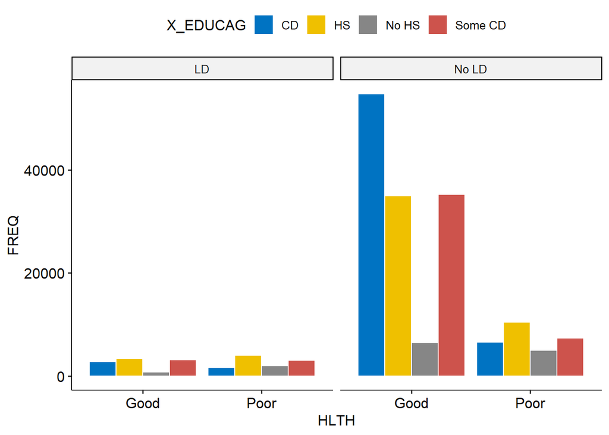

```r
ggplot(counts, aes(x=HLTH, y=FREQ))+geom_bar(aes(fill=X_EDUCAG),
                                             stat="identity",
                                             color="white",
                                             position=position_dodge(0.9)) + facet_wrap(~CHCCOPD1)+fill_palette("jco") #TK change colour
```

The counts of respondents with lung disease is significantly different across education and self-reported health (p < 0.01).For example, respondents with lung disease and poor self-reported health have lower proportions of college diplomas.

```r
#CHCCOPD1, DECIDE, X_RFHLTH.
mantelhaen.test(x=data$CHCCOPD1,
                y=data$DECIDE,
                z=data$X_RFHLTH,
                exact=FALSE)
```

```
##
##  Mantel-Haenszel chi-squared test with continuity correction
##
## data:  data$CHCCOPD1 and data$DECIDE and data$X_RFHLTH
## Mantel-Haenszel X-squared = 625.67, df = 1, p-value < 2.2e-16
## alternative hypothesis: true common odds ratio is not equal to 1
## 95 percent confidence interval:
##  NA NA
## sample estimates:
## common odds ratio
##          1.685596
```

```r
counts <- aggregate(data$CHCCOPD1, by=list(data$X_RFHLTH, data$DECIDE, data$CHCCOPD1), FUN=length)
names(counts) <- c("HLTH", "COGDEF", "CHCCOPD1", "FREQ")
counts$HLTH <- ifelse(counts$HLTH==1, "Good", "Poor")
counts$COGDEF <- ifelse(counts$COGDEF==1, "Deficits", "No Deficits")
counts$CHCCOPD1 <- ifelse(counts$CHCCOPD1==1, "LD", "No LD")
counts
```

```
##   HLTH      COGDEF CHCCOPD1   FREQ
## 1 Good    Deficits       LD   1035
## 2 Poor    Deficits       LD   2891
## 3 Good No Deficits       LD   9128
## 4 Poor No Deficits       LD   7896
## 5 Good    Deficits    No LD   5953
## 6 Poor    Deficits    No LD   5893
## 7 Good No Deficits    No LD 125256
## 8 Poor No Deficits    No LD  23399
```

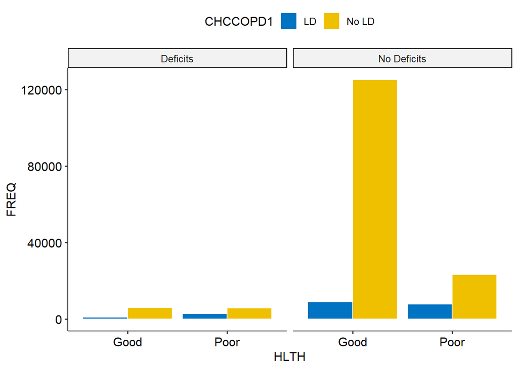

```r
ggplot(counts, aes(x=HLTH, y=FREQ))+geom_bar(aes(fill=CHCCOPD1),
                                             stat="identity",
                                             color="white",
                                             position=position_dodge(0.9)) + facet_wrap(~COGDEF)+fill_palette("jco") #TK change colour
```

The counts of respondents with cognitive deficits is significantly different across lung disease and self-reported health (p < 0.01).For example, respondents with lung disease and poor self-reported health have higher proportions of cognitive deficits.

USEEQUIP V. OTHER MEASURES.

```r
#USEEQUIP, DIABETE3, X_RFHLTH.
mantelhaen.test(x=data$USEEQUIP,
                y=data$DIABETE3,
                z=data$X_RFHLTH,
                exact=FALSE)
```

```
##
##  Mantel-Haenszel chi-squared test with continuity correction
##
## data:  data$USEEQUIP and data$DIABETE3 and data$X_RFHLTH
## Mantel-Haenszel X-squared = 1158.3, df = 1, p-value < 2.2e-16
## alternative hypothesis: true common odds ratio is not equal to 1
## 95 percent confidence interval:
##  NA NA
## sample estimates:
## common odds ratio
##          1.630941
```

```r
counts <- aggregate(data$USEEQUIP, by=list(data$X_RFHLTH, data$DIABETE3, data$USEEQUIP), FUN=length)
names(counts) <- c("HLTH", "DIABETE3", "USEEQUIP", "FREQ")
counts$HLTH <- ifelse(counts$HLTH==1, "Good", "Poor")
counts$DIABETE3 <- ifelse(counts$DIABETE3==1, "Diabetes", "No Diabetes")
counts$USEEQUIP <- ifelse(counts$USEEQUIP==1, "Uses Equip", "No Equip")
counts
```

```
##   HLTH    DIABETE3   USEEQUIP   FREQ
## 1 Good    Diabetes Uses Equip   3898
## 2 Poor    Diabetes Uses Equip   6771
## 3 Good No Diabetes Uses Equip  11258
## 4 Poor No Diabetes Uses Equip  10381
## 5 Good    Diabetes   No Equip  17796
## 6 Poor    Diabetes   No Equip   7912
## 7 Good No Diabetes   No Equip 109190
## 8 Poor No Diabetes   No Equip  15606
```

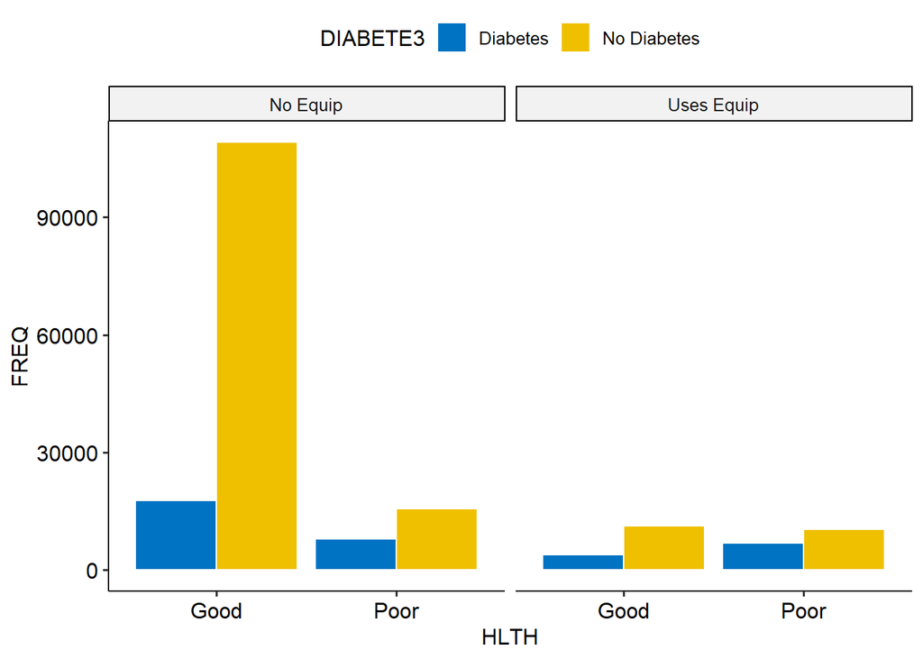

```r
ggplot(counts, aes(x=HLTH, y=FREQ))+geom_bar(aes(fill=DIABETE3),
                                             stat="identity",
                                             color="white",
                                             position=position_dodge(0.9)) + facet_wrap(~USEEQUIP)+fill_palette("jco") #TK change colour
```

The counts of respondents with special equipment requirements is significantly different across diabetes status and self-reported health (p < 0.01).For example, respondents with diabetes and poor self-reported health have higher proportions of special equipment requirements.

```r
#USEEQUIP, X_EDUCAG, X_RFHLTH.
mantelhaen.test(x=data$USEEQUIP,
                y=data$X_EDUCAG,
                z=data$X_RFHLTH,
                exact=FALSE) #not large enough M
```

```
##
##  Cochran-Mantel-Haenszel test
##
## data:  data$USEEQUIP and data$X_EDUCAG and data$X_RFHLTH
## Cochran-Mantel-Haenszel M^2 = 319.86, df = 3, p-value < 2.2e-16
```

```r
#USEEQUIP, DECIDE, X_RFHLTH.
mantelhaen.test(x=data$USEEQUIP,
                y=data$DECIDE,
                z=data$X_RFHLTH,
                exact=FALSE)
```

```
##
##  Mantel-Haenszel chi-squared test with continuity correction
##
## data:  data$USEEQUIP and data$DECIDE and data$X_RFHLTH
## Mantel-Haenszel X-squared = 1666.2, df = 1, p-value < 2.2e-16
## alternative hypothesis: true common odds ratio is not equal to 1
## 95 percent confidence interval:
##  NA NA
## sample estimates:
## common odds ratio
##          2.114685
```

```r
counts <- aggregate(data$USEEQUIP, by=list(data$X_RFHLTH, data$DECIDE, data$USEEQUIP), FUN=length)
names(counts) <- c("HLTH", "COGDEF", "USEEQUIP", "FREQ")
counts$HLTH <- ifelse(counts$HLTH==1, "Good", "Poor")
counts$COGDEF <- ifelse(counts$COGDEF==1, "Deficits", "No Deficits")
counts$USEEQUIP <- ifelse(counts$USEEQUIP==1, "Equip", "No Equip")
counts
```

```
##   HLTH      COGDEF USEEQUIP   FREQ
## 1 Good    Deficits    Equip   1732
## 2 Poor    Deficits    Equip   4745
## 3 Good No Deficits    Equip  13332
## 4 Poor No Deficits    Equip  12278
## 5 Good    Deficits No Equip   5298
## 6 Poor    Deficits No Equip   4179
## 7 Good No Deficits No Equip 121421
## 8 Poor No Deficits No Equip  19207
```

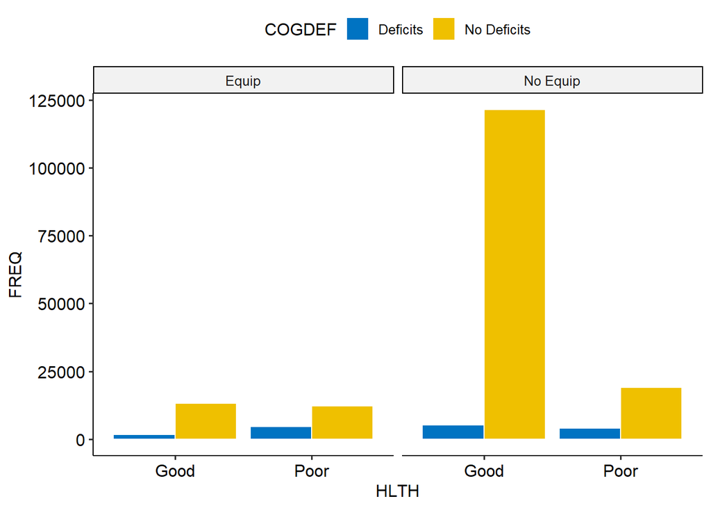

```r
ggplot(counts, aes(x=HLTH, y=FREQ))+geom_bar(aes(fill=COGDEF),
                                             stat="identity",
                                             color="white",
                                             position=position_dodge(0.9)) + facet_wrap(~USEEQUIP)+fill_palette("jco") #TK change colour
```

The counts of respondents with special equipment requirements is significantly different across cognitive deficits and self-reported health (p < 0.01).For example, respondents with cognitive deficits and poor self-reported health have higher proportions of special equipment requirements.

DIABETE3 V. OTHER VARIABLES.

```r
#DIABETE3, X_EDUCAG, X_RFHLTH.
mantelhaen.test(x=data$DIABETE3,
                y=data$X_EDUCAG,
                z=data$X_RFHLTH,
                exact=FALSE)
```

```
##
##  Cochran-Mantel-Haenszel test
##
## data:  data$DIABETE3 and data$X_EDUCAG and data$X_RFHLTH
## Cochran-Mantel-Haenszel M^2 = 788.3, df = 3, p-value < 2.2e-16
```

```r
counts <- aggregate(data$DIABETE3, by=list(data$X_RFHLTH, data$X_EDUCAG, data$DIABETE3), FUN=length)
names(counts) <- c("HLTH", "X_EDUCAG", "DIABETE3", "FREQ")
counts$HLTH <- ifelse(counts$HLTH==1, "Good", "Poor")
counts$X_EDUCAG <- ifelse(counts$X_EDUCAG==1, "No HS", ifelse(counts$X_EDUCAG==2, "HS", ifelse(counts$X_EDUCAG==3, "Some CD", "CD")))
counts$DIABETE3 <- ifelse(counts$DIABETE3==1, "Yes", "No")
counts
```

```
##    HLTH X_EDUCAG DIABETE3  FREQ
## 1  Good    No HS      Yes  1707
## 2  Poor    No HS      Yes  2825
## 3  Good       HS      Yes  6549
## 4  Poor       HS      Yes  5215
## 5  Good  Some CD      Yes  6292
## 6  Poor  Some CD      Yes  3864
## 7  Good       CD      Yes  7135
## 8  Poor       CD      Yes  2773
## 9  Good    No HS       No  5681
## 10 Poor    No HS       No  4223
## 11 Good       HS       No 31958
## 12 Poor       HS       No  9496
## 13 Good  Some CD       No 32173
## 14 Poor  Some CD       No  6675
## 15 Good       CD       No 50531
## 16 Poor       CD       No  5540
```

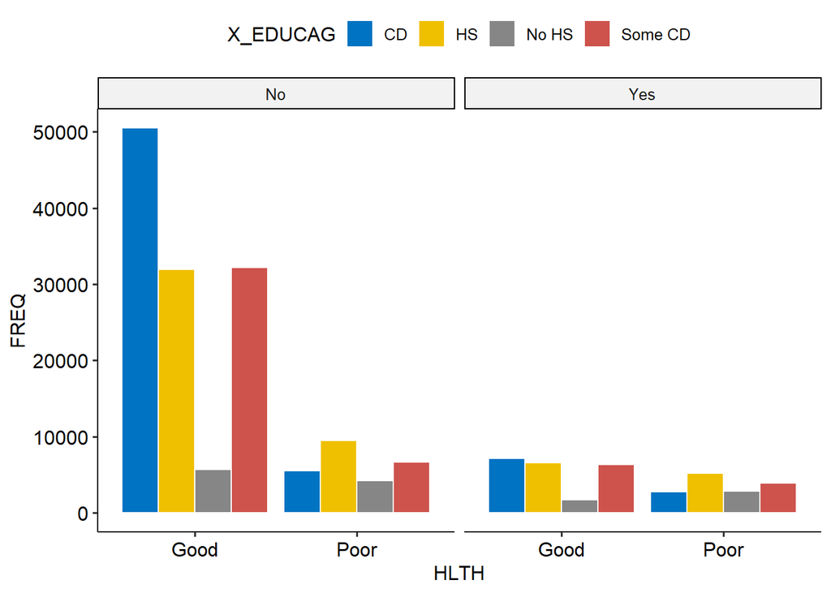

```r
ggplot(counts, aes(x=HLTH, y=FREQ))+geom_bar(aes(fill=X_EDUCAG),
                                             stat="identity",
                                             color="white",
                                             position=position_dodge(0.9)) + facet_wrap(~DIABETE3)+fill_palette("jco") #TK change colour
```

The counts of respondents with diabetes is significantly different across education and self-reported health (p < 0.01).For example, respondents with diabetes and poor self-reported health have lower proportions of college diplomas.

```r
#DIABETE3, DECIDE, X_RFHLTH.
mantelhaen.test(x=data$DIABETE3,
                y=data$DECIDE,
                z=data$X_RFHLTH,
                exact=FALSE)
```

```
##
##  Mantel-Haenszel chi-squared test with continuity correction
##
## data:  data$DIABETE3 and data$DECIDE and data$X_RFHLTH
## Mantel-Haenszel X-squared = 164.93, df = 1, p-value < 2.2e-16
## alternative hypothesis: true common odds ratio is not equal to 1
## 95 percent confidence interval:
##  NA NA
## sample estimates:
## common odds ratio
##           1.27628
```

```r
counts <- aggregate(data$DIABETE3, by=list(data$X_RFHLTH, data$DECIDE, data$DIABETE3), FUN=length)
names(counts) <- c("HLTH", "COGDEF", "DIABETE3", "FREQ")
counts$HLTH <- ifelse(counts$HLTH==1, "Good", "Poor")
counts$COGDEF <- ifelse(counts$COGDEF==1, "Deficits", "No Deficits")
counts$DIABETE3 <- ifelse(counts$DIABETE3==1, "Diabetes", "No Diabetes")
counts
```

```
##   HLTH      COGDEF    DIABETE3   FREQ
## 1 Good    Deficits    Diabetes   1548
## 2 Poor    Deficits    Diabetes   3377
## 3 Good No Deficits    Diabetes  20073
## 4 Poor No Deficits    Diabetes  11203
## 5 Good    Deficits No Diabetes   5485
## 6 Poor    Deficits No Diabetes   5527
## 7 Good No Deficits No Diabetes 114649
## 8 Poor No Deficits No Diabetes  20283
```

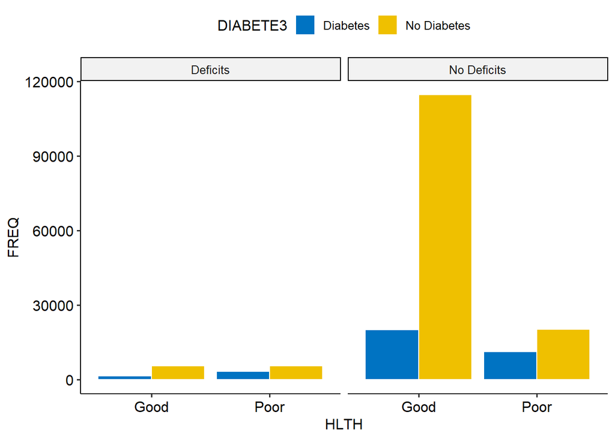

```r
ggplot(counts, aes(x=HLTH, y=FREQ))+geom_bar(aes(fill=DIABETE3),
                                             stat="identity",
                                             color="white",
                                             position=position_dodge(0.9)) + facet_wrap(~COGDEF)+fill_palette("jco") #TK change colour
```

The counts of respondents with diabetes is significantly different across cognitive deficits and self-reported health (p < 0.01).For example, respondents with diabetes and poor self-reported health have higher proportions of cognitive deficits.

```r
#DECIDE, X_EDUCAG, X_RFHLTH.
mantelhaen.test(x=data$DECIDE,
                y=data$X_EDUCAG,
                z=data$X_RFHLTH,
                exact=FALSE)
```

```
##
##  Cochran-Mantel-Haenszel test
##
## data:  data$DECIDE and data$X_EDUCAG and data$X_RFHLTH
## Cochran-Mantel-Haenszel M^2 = 1272.7, df = 3, p-value < 2.2e-16
```

```r
counts <- aggregate(data$DECIDE, by=list(data$X_RFHLTH, data$X_EDUCAG, data$DECIDE), FUN=length)
names(counts) <- c("HLTH", "X_EDUCAG", "DECIDE", "FREQ")
counts$HLTH <- ifelse(counts$HLTH==1, "Good", "Poor")
counts$X_EDUCAG <- ifelse(counts$X_EDUCAG==1, "No HS", ifelse(counts$X_EDUCAG==2, "HS", ifelse(counts$X_EDUCAG==3, "Some CD", "CD")))
counts$DECIDE <- ifelse(counts$DECIDE==1, "Deficits", "No Deficits")
counts
```

```
##    HLTH X_EDUCAG      DECIDE  FREQ
## 1  Good    No HS    Deficits   856
## 2  Poor    No HS    Deficits  1993
## 3  Good       HS    Deficits  2458
## 4  Poor       HS    Deficits  3203
## 5  Good  Some CD    Deficits  1947
## 6  Poor  Some CD    Deficits  2325
## 7  Good       CD    Deficits  1769
## 8  Poor       CD    Deficits  1392
## 9  Good    No HS No Deficits  6506
## 10 Poor    No HS No Deficits  5026
## 11 Good       HS No Deficits 35930
## 12 Poor       HS No Deficits 11416
## 13 Good  Some CD No Deficits 36416
## 14 Poor  Some CD No Deficits  8142
## 15 Good       CD No Deficits 55780
## 16 Poor       CD No Deficits  6851
```

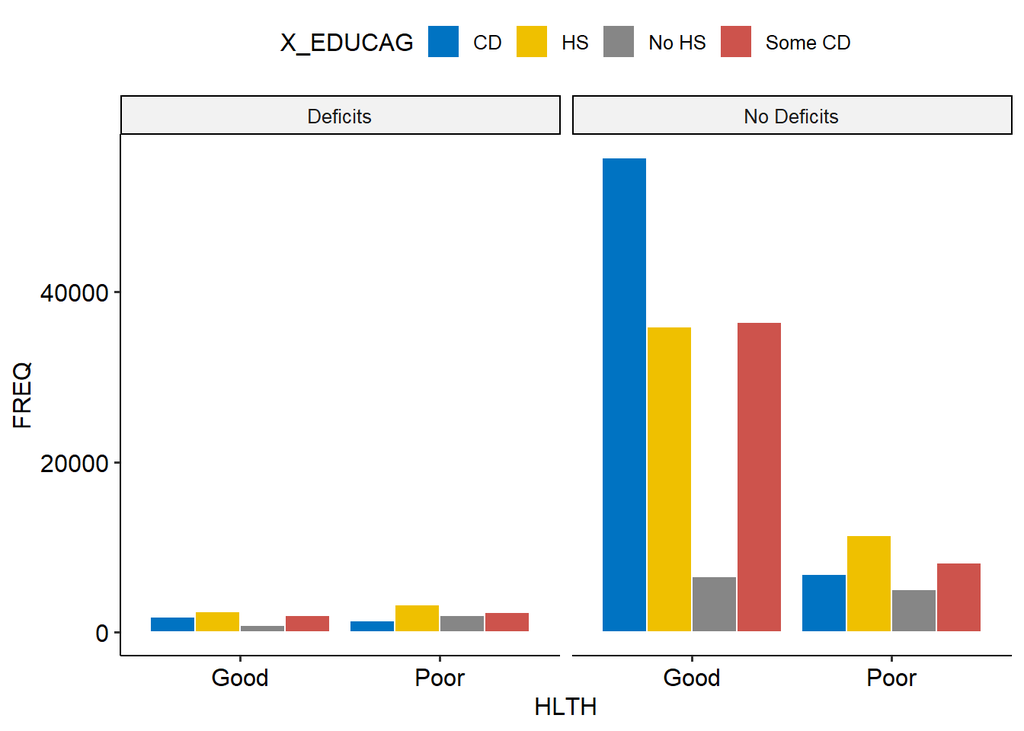

```r
ggplot(counts, aes(x=HLTH, y=FREQ))+geom_bar(aes(fill=X_EDUCAG),
                                             stat="identity",
                                             color="white",
                                             position=position_dodge(0.9)) + facet_wrap(~DECIDE)+fill_palette("jco") #TK change colour
```

The counts of respondents with cognitive deficits is significantly different across education and self-reported health (p < 0.01).For example, respondents with cognitive deficits and poor self-reported health have lower proportions of college diplomas.

```r
#EXRACT11.
#more likely to have a non-response
#EXRACT BY GENHLTH.
tail(sort(table(data$EXRACT11[data$X_RFHLTH==1])),
     n = 5)#64= walking
```

```
##
##     6    98    18     0    64
##  3201  4674  8242 33907 64736
```

```r
tail(sort(table(data$EXRACT11[data$X_RFHLTH==2])),
     n = 5) #0 = non-response
```

```
##
##     6    98    18    64     0
##   803  1228  1597 13358 20037
```

```r
#X_RFHLTH and QLACTLM2 == 1 (yes)
tail(sort(table(data$EXRACT11[data$X_RFHLTH==1 & data$QLACTLM2==1])),
     n = 5)
```

```
##
##     6    98    18     0    64
##   957  1314  1787 10318 12062
```

```r
tail(sort(table(data$EXRACT11[data$X_RFHLTH==2 & data$QLACTLM2==1])),
     n = 5)
```

```
##
##     6    98    18    64     0
##   543   879   948  7702 13879
```

```r
#X_RFHLTH and QLACTLM2 == 2 (no)
tail(sort(table(data$EXRACT11[data$X_RFHLTH==1 & data$QLACTLM2==2])),
     n = 5)
```

```
##
##     2    98    18     0    64
##  2363  3326  6410 23412 52343
```

```r
tail(sort(table(data$EXRACT11[data$X_RFHLTH==2 & data$QLACTLM2==2])),
     n = 5)
```

```
##
##    6   98   18   64    0
##  253  339  638 5549 6052
```

```r
#X_RFHLTH and QLACTLM2 == 1 (yes)
tail(sort(table(data$EXRACT11[data$X_RFHLTH==1 & data$QLACTLM2==1])),
     n = 5)
```

```
##
##     6    98    18     0    64
##   957  1314  1787 10318 12062
```

```r
tail(sort(table(data$EXRACT11[data$X_RFHLTH==2 & data$QLACTLM2==1])),
     n = 5)
```

```
##
##     6    98    18    64     0
##   543   879   948  7702 13879
```

```r
#X_RFHLTH and QLACTLM2 == 2 (no)
tail(sort(table(data$EXRACT11[data$X_RFHLTH==1 & data$QLACTLM2==2])),
     n = 5)
```

```
##
##     2    98    18     0    64
##  2363  3326  6410 23412 52343
```

```r
tail(sort(table(data$EXRACT11[data$X_RFHLTH==2 & data$QLACTLM2==2])),
     n = 5)
```

```
##
##    6   98   18   64    0
##  253  339  638 5549 6052
```

Overall, the top ten important variables have a compounding effect on general health. As an individual experiences more mobility limitations and disease, the more days are spent in poor physical and mental health. As a consequence, they are more likely to self-report poor health.

This effect is also impacted by education–where less educated individuals are more likely to have poor physical health when combined with another disease.